# Prompting R: Using AI + RStudio for Stats & Visualization

2025-09-21

# Why this handout

Use **natural‑language prompts** with an AI assistant (like ChatGPT) to produce **clean, runnable R code** in RStudio for common statistics and plots-without over‑emphasizing syntax. You’ll see **prompt patterns**, **checklists**, and **ready‑to‑run examples**.

# Quick rules for great prompts

- **Goal + Data + Output.** Say what you want, which dataset/columns, and the output (plot, test, model).
- **Name tools.** e.g., “Use `ggplot2`” or “base R only.”
- **Be concrete.** Provide column names and data types.
- **Iterate.** Ask for edits (titles, colors, grouping).
- **Ask for comments.** “Add comments to each step.”
- **Paste errors back.** “Explain this error and fix it.”

**Copy‑me template:**

> I’m in RStudio. I have a data frame `DF` with columns: `y` (numeric), `x` (numeric), `group` (factor). Make a scatterplot of `y` vs `x`, color by `group`, add loess smoothers, and nice axis labels. Use `ggplot2`. Give me **only runnable R code** with comments.

# Minimal dependencies

The examples below use base R and **ggplot2**.

```r
if (!requireNamespace("ggplot2", quietly = TRUE)) install.packages("ggplot2")
library(ggplot2)
```

# Prompt → Code: common tasks

## 1) Load a CSV and inspect

**Good prompt:**

> “Read `data/my_study.csv`, show first rows, column names, and a basic summary. Report missing values by column. Code only.”

```r
path <- "data/my_study.csv"
if (file.exists(path)) {
  dat <- read.csv(path, stringsAsFactors = FALSE)
  cat("Rows x Cols:", nrow(dat), "x", ncol(dat), "\n")
  cat("Column names:\n"); print(names(dat))
  cat("\nMissing values per column:\n"); print(colSums(is.na(dat)))
  cat("\nSummary:\n"); print(summary(dat))
} else {
  cat("Demo mode: file not found; using built-in 'mtcars'.\n")
  dat <- mtcars
  dat$cyl <- factor(dat$cyl)
  print(head(dat))
}
```

```
## Demo mode: file not found; using built-in 'mtcars'.
##                    mpg cyl disp  hp drat    wt  qsec vs am gear carb
## Mazda RX4         21.0   6  160 110 3.90 2.620 16.46  0  1    4    4
## Mazda RX4 Wag     21.0   6  160 110 3.90 2.875 17.02  0  1    4    4
## Datsun 710        22.8   4  108  93 3.85 2.320 18.61  1  1    4    1
## Hornet 4 Drive    21.4   6  258 110 3.08 3.215 19.44  1  0    3    1
## Hornet Sportabout 18.7   8  360 175 3.15 3.440 17.02  0  0    3    2
## Valiant           18.1   6  225 105 2.76 3.460 20.22  1  0    3    1
```

## 2) Clean/transform (base R only)

**Good prompt:**

> “Recode `group` to factor, drop rows with missing `y` or `x`, create `log_y = log(y)`. Base R only, with comments.”

```r
df <- dat
if ("cyl" %in% names(df)) df$cyl <- factor(df$cyl)  # demo grouping
df <- df[!is.na(df$mpg) & !is.na(df$wt), ]          # demo: keep complete rows
df$log_mpg <- log(df$mpg)
summary(df$log_mpg)
```

```
##    Min. 1st Qu.  Median    Mean 3rd Qu.    Max.
##   2.342   2.736   2.955   2.958   3.127   3.523
```

## 3) Plot beautifully with ggplot2

**Good prompt:**

> “Scatterplot `mpg` vs `wt`, color by `cyl`, smooth per group, minimal theme, clear labels.”

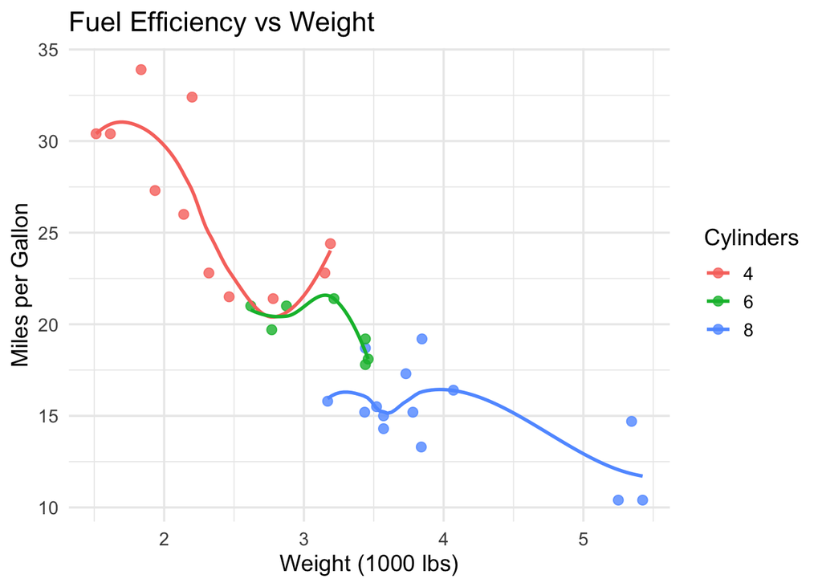

```r
ggplot(df, aes(x = wt, y = mpg, color = cyl)) +
  geom_point(alpha = 0.8, size = 2.5) +
  geom_smooth(se = FALSE) +
  labs(
    title = "Fuel Efficiency vs Weight",
    x = "Weight (1000 lbs)",
    y = "Miles per Gallon",
    color = "Cylinders"
  ) +
  theme_minimal(base_size = 14)
```

## 4) Two‑group comparison (Welch’s t‑test) + effect size

**Good prompt:**

> “Compare `mpg` between 4‑ and 6‑cyl. Welch’s t‑test, Cohen’s d, one‑sentence interpretation.”

```r
sub <- df[df$cyl %in% c("4", "6"), ]
x <- sub$mpg[sub$cyl == "4"]; y <- sub$mpg[sub$cyl == "6"]
tt <- t.test(x, y)  # Welch by default
d  <- (mean(x) - mean(y)) / sqrt((sd(x)^2 + sd(y)^2)/2)
tt
```

```
##
##  Welch Two Sample t-test
##
## data:  x and y
## t = 4.7191, df = 12.956, p-value = 0.0004048
## alternative hypothesis: true difference in means is not equal to 0
## 95 percent confidence interval:
##   3.751376 10.090182
## sample estimates:
## mean of x mean of y
##  26.66364  19.74286
```

```r
cat(sprintf("Cohen's d = %.2f\n", d))
```

```
## Cohen's d = 2.07
```

```r
cat(sprintf("Interpretation: Mean mpg differs between 4- and 6-cylinder cars (t=%.2f, p=%.3f); effect size d=%.2f.\n",
            unname(tt$statistic), tt$p.value, d))
```

```
## Interpretation: Mean mpg differs between 4- and 6-cylinder cars (t=4.72, p=0.000); effect size d=2.07.
```

## 5) One‑way ANOVA + diagnostics + Tukey

**Good prompt:**

> “ANOVA `mpg ~ cyl`, residual plot + QQ plot + Shapiro, Tukey post‑hoc if significant. One‑line takeaway.”

```r
fit <- aov(mpg ~ cyl, data = df)
summary(fit)
```

```
##             Df Sum Sq Mean Sq F value   Pr(>F)
## cyl          2  824.8   412.4    39.7 4.98e-09 ***
## Residuals   29  301.3    10.4
## ---
## Signif. codes:  0 '***' 0.001 '**' 0.01 '*' 0.05 '.' 0.1 ' ' 1
```

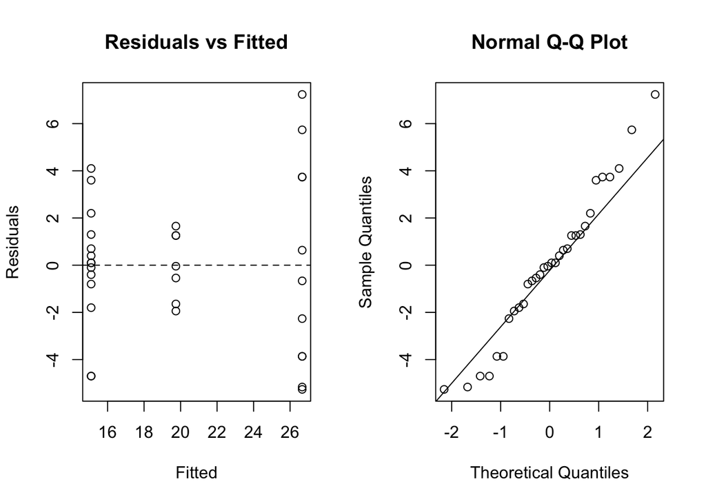

```r
par(mfrow = c(1, 2))
plot(fitted(fit), resid(fit), xlab="Fitted", ylab="Residuals", main="Residuals vs Fitted"); abline(h=0, lty=2)
qqnorm(resid(fit)); qqline(resid(fit))
```

```r
par(mfrow = c(1, 1))

shapiro <- shapiro.test(resid(fit)); shapiro
```

```
##
##  Shapiro-Wilk normality test
##
## data:  resid(fit)
## W = 0.97065, p-value = 0.5177
```

```r
p_anova <- summary(fit)[[1]]["cyl","Pr(>F)"]
if (!is.na(p_anova) && p_anova < 0.05) {
  tk <- TukeyHSD(fit, "cyl"); print(tk)
  cat("Takeaway: Cylinders explain mpg differences; see Tukey pairs.\n")
} else {
  cat("Takeaway: No strong evidence that mpg differs by cylinders.\n")
}
```

```
##   Tukey multiple comparisons of means
##     95% family-wise confidence level
##
## Fit: aov(formula = mpg ~ cyl, data = df)
##
## $cyl
##           diff        lwr        upr     p adj
## 6-4  -6.920779 -10.769350 -3.0722086 0.0003424
## 8-4 -11.563636 -14.770779 -8.3564942 0.0000000
## 8-6  -4.642857  -8.327583 -0.9581313 0.0112287
##
## Takeaway: Cylinders explain mpg differences; see Tukey pairs.
```

## 6) Linear regression with standardized effects

**Good prompt:**

> “Fit `mpg ~ wt + hp`. Report standardized betas and R². One‑sentence interpretation.”

```r
Z <- scale(df[, c("wt", "hp")])
fit_lm <- lm(df$mpg ~ Z[, "wt"] + Z[, "hp"])
summary(fit_lm)
```

```
##
## Call:
## lm(formula = df$mpg ~ Z[, "wt"] + Z[, "hp"])
##
## Residuals:
##    Min     1Q Median     3Q    Max
## -3.941 -1.600 -0.182  1.050  5.854
##
## Coefficients:
##             Estimate Std. Error t value Pr(>|t|)
## (Intercept)  20.0906     0.4585  43.822  < 2e-16 ***
## Z[, "wt"]    -3.7943     0.6191  -6.129 1.12e-06 ***
## Z[, "hp"]    -2.1784     0.6191  -3.519  0.00145 **
## ---
## Signif. codes:  0 '***' 0.001 '**' 0.01 '*' 0.05 '.' 0.1 ' ' 1
##
## Residual standard error: 2.593 on 29 degrees of freedom
## Multiple R-squared:  0.8268, Adjusted R-squared:  0.8148
## F-statistic: 69.21 on 2 and 29 DF,  p-value: 9.109e-12
```

```r
cat("Interpretation: Holding the other predictor constant, a 1 SD increase in a predictor changes mpg by its standardized beta.\n")
```

```
## Interpretation: Holding the other predictor constant, a 1 SD increase in a predictor changes mpg by its standardized beta.
```

# Prompt patterns (copy/paste)

**Explain + code**

> “Act as a stats tutor. In RStudio with `DF(col1 numeric, col2 factor)`, run a **Welch’s t‑test** comparing `col1` across `col2` groups, include **comments**, and explain the output in **2 sentences**.”

**Plot with constraints**

> “Use **base R only** to draw **side‑by‑side boxplots** of `y` by `group` from `DF`. Add a title and axis labels. Code only.”

**Reproduce & compare**

> “Give two solutions to plot `y ~ x` with a smooth: one using **base R** and one using **ggplot2**. Label axes and set a white background.”

**Troubleshoot**

> “I get `object 'Sepal.Length' not found`. Here is my code: [paste]. Explain the error and give a fixed version.”

# Error‑driven workflow

1. **Paste the exact error** into your AI prompt.
2. **Include the code** (or the failing line).
3. **State what you expected** (“I wanted a plot with three groups”).
4. **Ask for a fix + explanation**.

# Built‑in practice datasets

- **`iris`** - sepal/petal by species. **Load:** `data(iris); head(iris)`
- **`mtcars`** - car performance stats. **Load:** `data(mtcars); head(mtcars)`
- **`ToothGrowth`** - tooth length by supplement & dose. **Load:** `data(ToothGrowth); head(ToothGrowth)`

# Exercises (prompt → code → interpret)

1. **T‑test (ToothGrowth):** Compare tooth length by `supp`. Plot (violin/boxplot), Welch’s t‑test, effect size, one‑sentence interpretation.
2. **ANOVA (iris):** Test whether `Sepal.Length` differs by `Species`. Diagnostics + Tukey; plot means with 95% CIs.
3. **Regression (mtcars):** Model `mpg ~ wt + hp`. Report standardized betas, R², and a partial‑effect plot for `wt` controlling for `hp`.

# Copy‑me prompt + scaffold

**Prompt to paste into AI:**

> I’m in RStudio. I have `DF` with `y` (numeric outcome), `x` (numeric predictor), `grp` (factor). Please produce **only runnable R code** that:
> 1. Removes rows with missing `y` or `x`.
> 2. Makes a scatterplot of `y` vs `x`, color by `grp`, with a smooth per group.
> 3. Fits `y ~ x + grp` and reports coefficients and R².
> 4. Uses **ggplot2**, includes **comments**, runs as‑is.

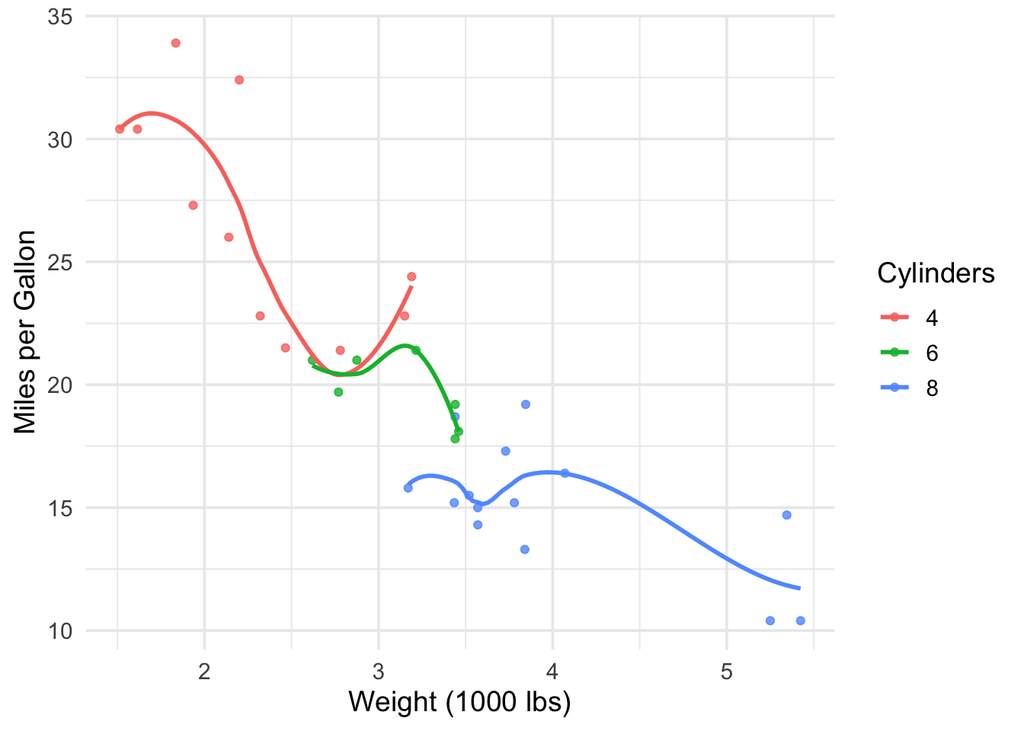

```r
DF <- mtcars; DF$grp <- factor(DF$cyl)  # replace with your data
DF <- DF[!is.na(DF$mpg) & !is.na(DF$wt), ]

ggplot(DF, aes(wt, mpg, color = grp)) +
  geom_point(alpha = 0.8) +
  geom_smooth(se = FALSE) +
  labs(x = "Weight (1000 lbs)", y = "Miles per Gallon", color = "Cylinders") +
  theme_minimal(base_size = 14)
```

```r
fit <- lm(mpg ~ wt + grp, data = DF)
summary(fit)
```

```
##
## Call:
## lm(formula = mpg ~ wt + grp, data = DF)
##
## Residuals:
##     Min      1Q  Median      3Q     Max
## -4.5890 -1.2357 -0.5159  1.3845  5.7915
##
## Coefficients:
##             Estimate Std. Error t value Pr(>|t|)
## (Intercept)  33.9908     1.8878  18.006  < 2e-16 ***
## wt           -3.2056     0.7539  -4.252 0.000213 ***
## grp6         -4.2556     1.3861  -3.070 0.004718 **
## grp8         -6.0709     1.6523  -3.674 0.000999 ***
## ---
## Signif. codes:  0 '***' 0.001 '**' 0.01 '*' 0.05 '.' 0.1 ' ' 1
##
## Residual standard error: 2.557 on 28 degrees of freedom
## Multiple R-squared:  0.8374, Adjusted R-squared:   0.82
## F-statistic: 48.08 on 3 and 28 DF,  p-value: 3.594e-11
```

# Mini cheat‑sheet: which test?

- **Two groups, numeric outcome:** Welch’s **t‑test**.
- **>2 groups, numeric outcome:** **ANOVA** (+ Tukey).
- **Numeric outcome + predictors:** **Linear regression**.
- **Counts:** **Chi‑square** or **Poisson/Logistic GLM**.
- **Assumption issues:** Use **non‑parametrics** (Wilcoxon/Kruskal–Wallis), transforms, or appropriate **GLMs**.

*End.*